# Twitter newspapers

## Hassan Abdullah

## website: https://hassan6633.github.io/mis492/

# newspapers:

- Alwatan
- Alseyasseyah
- Aldaar
- Alrai
- Alanbaa
- Alqabas
- Alnahar
- Aljareda

## 1- newspapers followers

## 2- newspapers tweets

# Tools of data collection:

- tweepy
- collected through API

# Tools of analysis:

- matplotlib.pyplot
- pandas
- seaborn
- numpy
- matplotlib.dates

# Followers:

| **Variables** | **Description** | **Data type** | **Notes** |
| --- | --- | --- | --- |
| created_at | date the account was created at | datetime64, Categorical | converted from object to datetime64 |
| default_profile_image | shows the type of the profile image if its the defualt image or not | object, Categorical |  |
| description | bio of the account | object, Categorical |  |
| favourites_count | hows the number of the account likes on tweets | float64, Nominal |  |
| followers_count | followers of the account | float64, Nominal |  |
| friends_count | people that the account is following | float64, Nominal | converted from object to float64 |
| geo_enabled | location of the account user | object, Categorical |  |
| id | id of the account | object, Nominal |  |
| listed_count | number of public lists the user have or member of | float64, Nominal | converted from object to float64 |
| location | the location of the user | object, Categorical |  |
| profile_background_color | color of the background | object, Categorical |  |
| profile_background_image_url | url of the background image | object, Nominal |  |
| profile_text_color | color of the profile text | object, Nominal |  |
| profile_use_background_image | the type of the backgrond image if its the original or changed | object, Categorical |  |
| protected | is the account private or not | object, Categorical |  |
| screen_name | username of the account | object, Categorical |  |
| statuses_count | number of tweets | float64, continuous |  |
| url | the url account has in his profile | object, Categorical |  |
| name | name of the newspaper | object, Categorical | i added this column |
| tweets_mean | average number of tweets | float64, continuous | i added this column |

- **contributors_enabled** : this column was not used in the analysis because its definition was not known
- **default_profile** : this column was not used in the analysis because its definition was not known
- **profile_background_tile** : this column was not used in the analysis because its definition was not known
- **verified** : this column was not used in the analysis because its definition was not known

```python
#removed any duplicates between the followers

followers_df2 = followers_df[~followers_df[["screen_name","name"]].duplicated()]
```

- aldaar followers are the more active in twitter over other newspapers followers

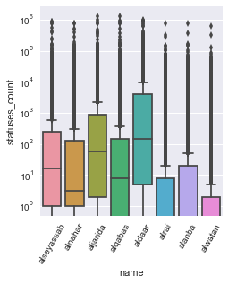

- followers of the newspapers that created there account between 2012 and 2013 have the most number of tweets (a political problems at period may pushed people to open twitter accounts and follow the newspapers to follow up news and interact with it)

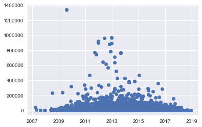

# Tweets:

| **Variables** | **Description** | **Data type** | **Notes** |
| --- | --- | --- | --- |
| craeted_at | date the tweet was created | datetime, continuous | converted from object to datetime |
| entities | any entity the tweet has (hashtags, symbols, mentions) | object, categorical |  |
| favorite_count | number of likes the tweet has | float64, continuous |  |
| id | id of the tweet | float64, continuous |  |
| in_reply_to_screen_name | if the tweet has reply (show screen name) | object, categorical |  |
| in_reply_to_status_id | if the tweet has reply (show tweet id) | float64, continuous |  |
| in_reply_to_user_id | if the tweet has reply (show user id) | float64, continuous |  |
| place | place the tweet was tweeted from | object, categorical | all the data was NaN so i excluded the column |
| possibly_sensitive | if there are any sensitive content in the tweet | object, categorical | all the data was False so i excluded the column |
| retweet_count | number of retweets | float64, continuous |  |
| text | the text of the tweet | object, categorical |  |
| name | the name of the neawspaper | object, categorical | i added this column |
| retweet_mean | average number of retweets | float64, continuous | i added thid column |

- alwatan have the highest average of tweets likes (is it because people like the tweets more than other newspapers tweets or because it have more follwers?)

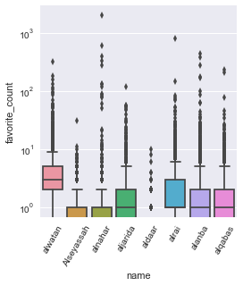

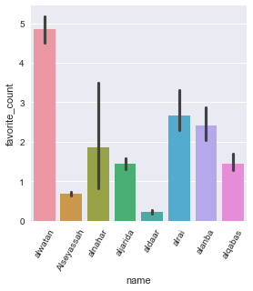

- alseyaseyah have people reply more than other newspapers but retweets less than other people (the newspaper tweets may not reflect followers thoughts and opinions or the people is replying with somthing they didn't like about the tweet)

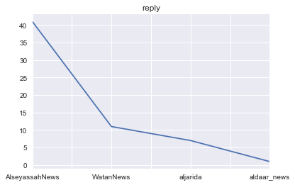

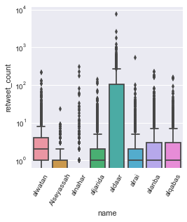

- alwatan have above average number of retweets and alseyassah have below average number of retweets
- although aldaar is below average, it has the most retweets as outlayers(thats may be because it can get the intresting news that people intrested in faster than other newspapers for some types of news)

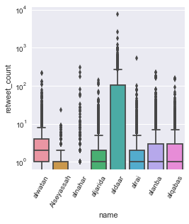

- most retweets for all the newspapers are between 0 to 800

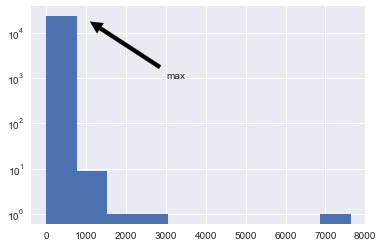

- if i had more time to get more data like the followers of the newspapers accounts and to explore more there may be more intresting and accurate results to find.